# SuperKart Project

## Context:

A sales forecast is a prediction of future sales revenue based on historical data, industry trends, and the status of the current sales pipeline. Businesses use the sales forecast to estimate weekly, monthly, quarterly, and annual sales totals. It is extremely important for a company to make an accurate sales forecast as it adds value across an organization and helps the different verticals to chalk out their future course of actions. Forecasting helps an organization to plan its sales operations by regions and provide valuable insights to the supply chain team regarding the procurement of goods and materials. An accurate sales forecast process has many benefits which include improved decision-making about the future and reduction of sales pipeline and forecast risks. Moreover, it helps to reduce the time spent in planning territory coverage and establish benchmarks that can be used to assess trends in the future.

## Objective:

SuperKartKart is an organization which owns a chain of supermarkets and food marts providing a wide range of products. They want to predict the future sales revenue of its different outlets so that they can strategize their sales operation across different tier cities and plan their inventory accordingly. To achieve this purpose, SuperKart has hired a data science firm, shared the sales records of its various outlets for the previous quarter and asked the firm to come up with a suitable model to predict the total sales of the stores for the upcoming quarter.

## Data Description:

The data contains the different attributes of the various products and stores.The detailed data dictionary is given below.

- Product_Id - unique identifier of each product, each identifier having two letters at the beginning followed by a number
- Product_Weight - weight of each product
- Product_Sugar_Content - sugar content of each product like low sugar, regular and no sugar
- Product_Allocated_Area - ratio of the allocated display area of each product to the total display area of all the products in a store
- Product_Type - broad category for each product like meat, snack foods, hard drinks, dairy, canned, soft drinks, health and hygiene, baking goods, breads, breakfast, frozen foods, fruits and vegetables, household, seafood, starchy foods, others
- Product_MRP - maximum retail price of each product
- Store_Id - unique identifier of each store
- Store_Establishment_Year - year in which the store was established
- Store_Size - size of the store depending on sq. feet like high, medium and low
- Store_Location_City_Type - type of city in which the store is located like Tier 1, Tier 2 and Tier 3. Tier 1 consists of cities where the standard of living is comparatively higher than its Tier 2 and Tier 3 counterparts.
- Store_Type - type of store depending on the products that are being sold there like Departmental Store, Supermarket Type 1, Supermarket Type 2 and Food Mart
- Product_Store_Sales_Total - total revenue generated by the sale of that particular product in that particular store

## Importing necessary libraries and data

```python
import warnings
warnings.filterwarnings("ignore")

import numpy as np
import pandas as pd

import seaborn as sns
import matplotlib.pyplot as plt

from sklearn.tree import DecisionTreeRegressor
from sklearn.ensemble import BaggingRegressor,RandomForestRegressor, GradientBoostingRegressor, AdaBoostRegressor, StackingRegressor
from xgboost import XGBRegressor
from sklearn import metrics
from sklearn.model_selection import GridSearchCV, train_test_split
```

```python
from sklearn.metrics import r2_score, mean_squared_error, mean_absolute_error
```

```python
from google.colab import drive
drive.mount('/content/drive')
```

```python
df = pd.read_csv("/content/drive/MyDrive/SuperKart.csv")
```

```python
df.isnull().sum()
```

```
Product_Id                   0
Product_Weight               0
Product_Sugar_Content        0
Product_Allocated_Area       0
Product_Type                 0
Product_MRP                  0
Store_Id                     0
Store_Establishment_Year     0
Store_Size                   0
Store_Location_City_Type     0
Store_Type                   0
Product_Store_Sales_Total    0
dtype: int64
```

## Data Overview

- Observations
- Sanity checks

## Exploratory Data Analysis (EDA)

- EDA is an important part of any project involving data.
- It is important to investigate and understand the data better before building a model with it.
- A few questions have been mentioned below which will help you approach the analysis in the right manner and generate insights from the data.
- A thorough analysis of the data, in addition to the questions mentioned below, should be done.

**Questions**

- Different varieties of products are available at stores. A store needs to plan its inventory appropriately which is well aligned to the supply and demand characteristics. Which product type is contributing the most to the revenue of the company (SuperKart)?
- Location may have a high impact on the revenue of a store. Find out the type of stores and locations that are having a high impact on the revenue of the company.
- Nowadays many customers prefer products that have low sugar content in them. How many items have been sold in each of the 16 product types that have low sugar content in them?
- Which product type has been sold the most number of times in each of the stores? Which product type is contributing the most to the revenue of the individual stores?
- There are some stores of a company that generally sell only premium items having higher prices than others. Which store has sold more costly goods than others?

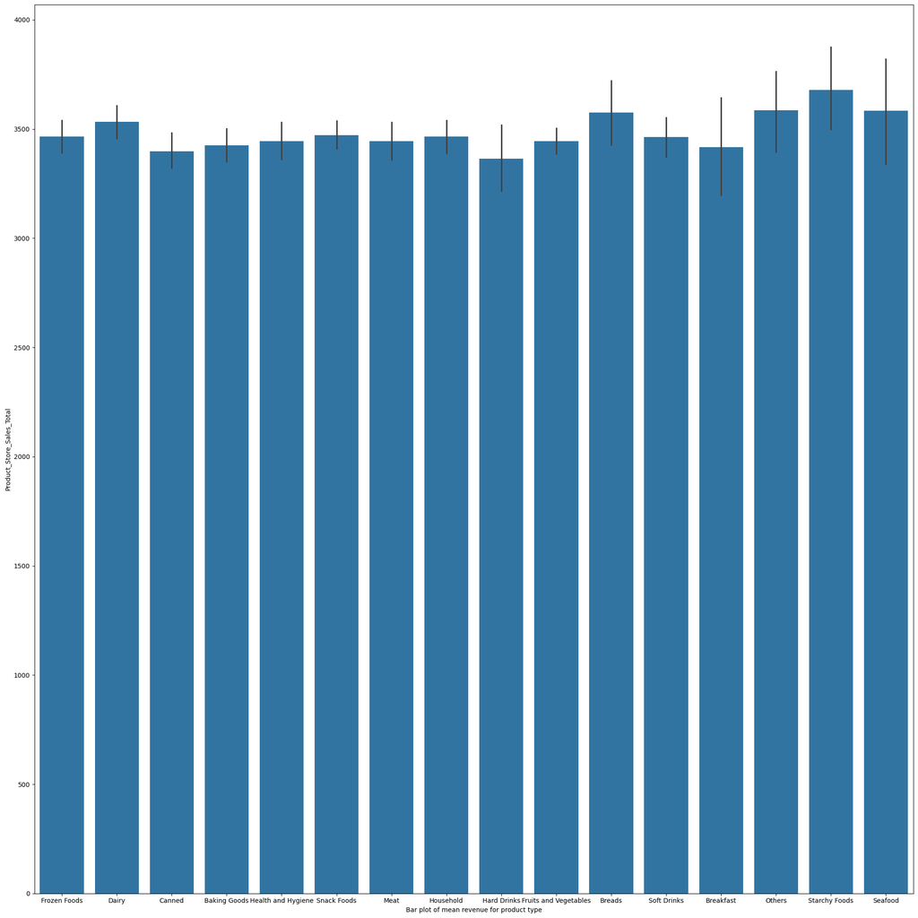

```python
plt.figure(figsize=(20,20))
sns.barplot(df, x = "Product_Type", y = "Product_Store_Sales_Total")
plt.xlabel("Bar plot of mean revenue for product type")
plt.tight_layout()
plt.show()
```

```python
rev_fraction = []
for i in df["Product_Type"].unique():
  dummy_df = df.loc[df["Product_Type"] == i]
  product_type_rev = dummy_df["Product_Store_Sales_Total"].sum()
  rev_fraction.append(product_type_rev)
  print(product_type_rev, i)
#df2.head()
```

```
2809980.83 Frozen Foods
2811918.04 Dairy
2300082.71 Canned
2452986.0 Baking Goods
2163707.21 Health and Hygiene
3988996.95 Snack Foods
2129211.9400000004 Meat
2564740.17 Household
625814.62 Hard Drinks
4300833.27 Fruits and Vegetables
714942.24 Breads
1797044.7200000002 Soft Drinks
362130.41000000003 Breakfast
541496.3 Others
518774.45000000007 Starchy Foods
272404.04 Seafood
```

```python
product_type_rev_data = {"Product_Type" : df["Product_Type"].unique(),
                         "Revenue_For_Type": rev_fraction}

product_type_rev_df = pd.DataFrame(product_type_rev_data)

product_type_rev_df.head()
```

|  | Product_Type | Revenue_For_Type |
| --- | --- | --- |
| 0 | Frozen Foods | 2809980.83 |
| 1 | Dairy | 2811918.04 |
| 2 | Canned | 2300082.71 |
| 3 | Baking Goods | 2452986.00 |
| 4 | Health and Hygiene | 2163707.21 |

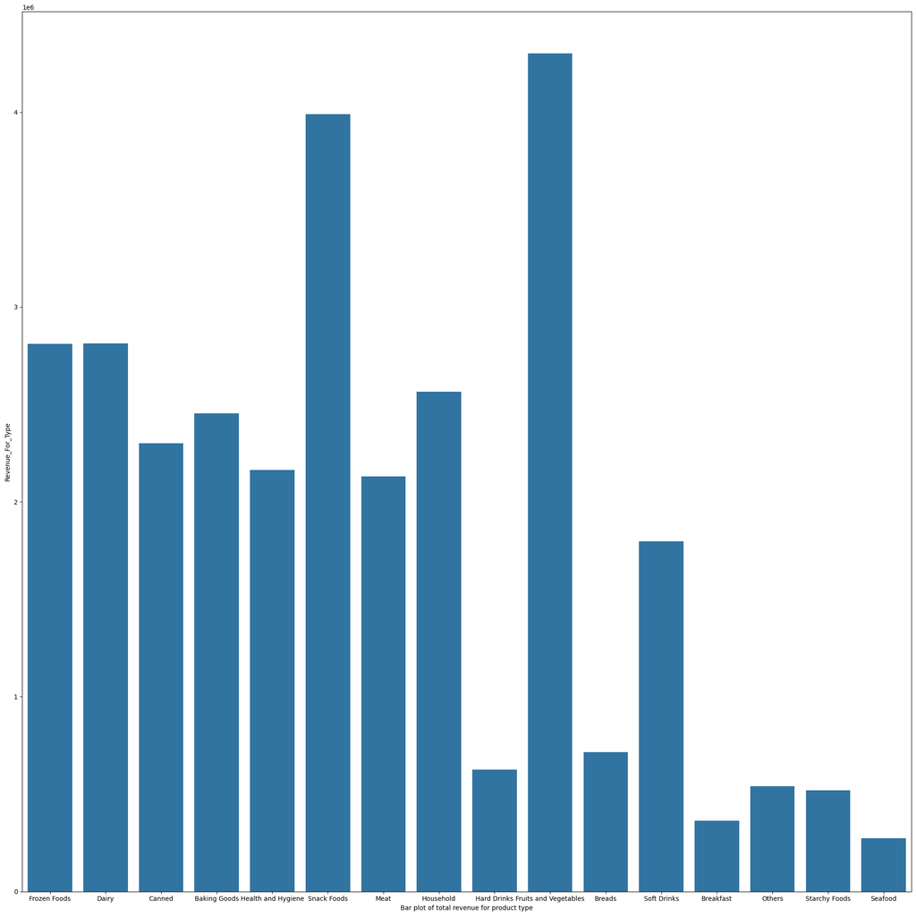

```python
plt.figure(figsize=(20,20))
sns.barplot(product_type_rev_df, x = "Product_Type", y ="Revenue_For_Type")
plt.xlabel("Bar plot of total revenue for product type")
plt.tight_layout()
plt.show()
```

This barplot shows how much total revenue is brought in by each product type. Revenue is in reference to the entire company, not the individual stores. The product type with the highest revenue is fruits and vegetables.

```python
rev_fraction = []
for i in df["Store_Type"].unique():
  dummy_df = df.loc[df["Store_Type"] == i]
  store_type_rev = dummy_df["Product_Store_Sales_Total"].sum()
  rev_fraction.append(store_type_rev)
  print(store_type_rev, i)
#df2.head()
```

```
15427583.43 Supermarket Type2
6673457.57 Departmental Store
6223113.18 Supermarket Type1
2030909.72 Food Mart
```

```python
store_type_rev_data = {"Store_Type" : df["Store_Type"].unique(),
                         "Revenue_For_Type": rev_fraction}

store_type_rev_df = pd.DataFrame(store_type_rev_data)

store_type_rev_df.head()
```

|  | Store_Type | Revenue_For_Type |
| --- | --- | --- |
| 0 | Supermarket Type2 | 15427583.43 |
| 1 | Departmental Store | 6673457.57 |
| 2 | Supermarket Type1 | 6223113.18 |
| 3 | Food Mart | 2030909.72 |

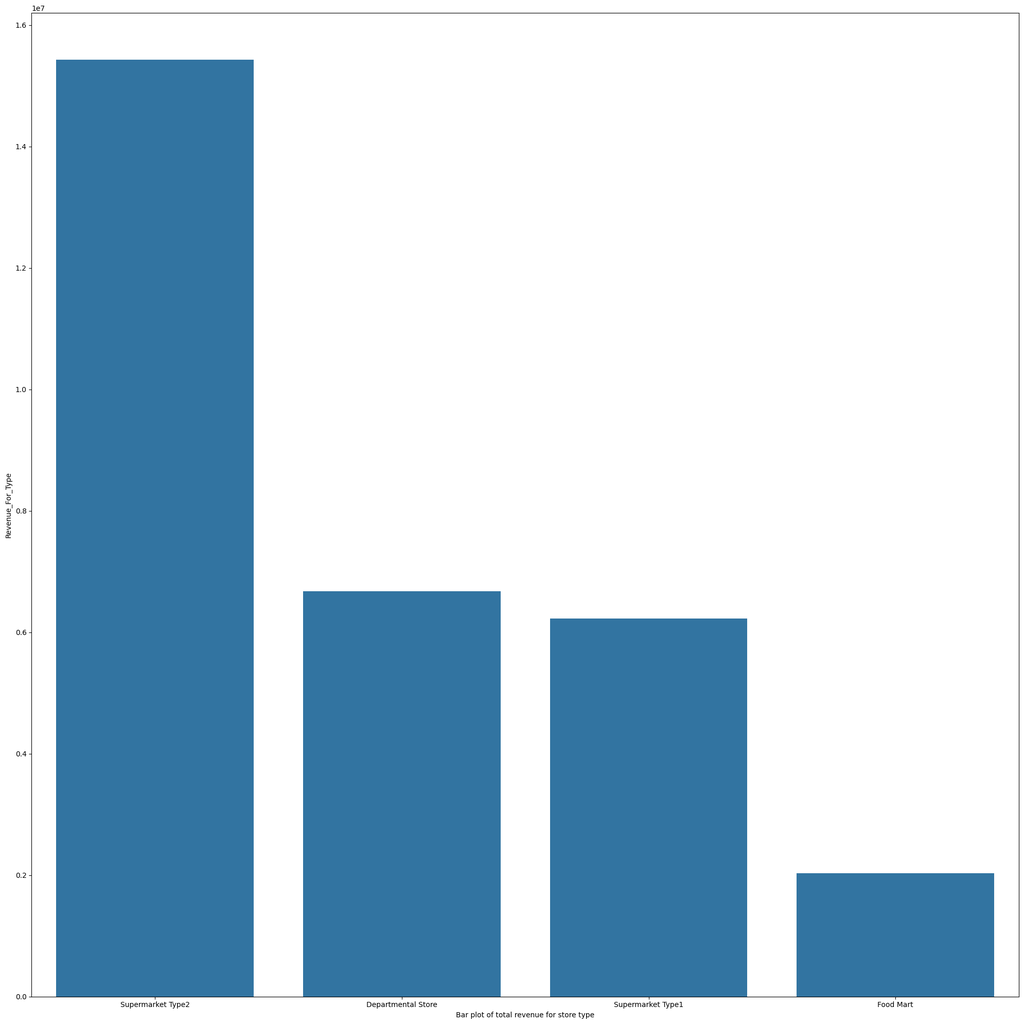

```python
plt.figure(figsize=(20,20))
sns.barplot(store_type_rev_df, x = "Store_Type", y ="Revenue_For_Type")
plt.xlabel("Bar plot of total revenue for store type")
plt.tight_layout()
plt.show()
```

This is the same method but applied to the category of store type. The store type with the highest revenue is the type 2 supermarket.

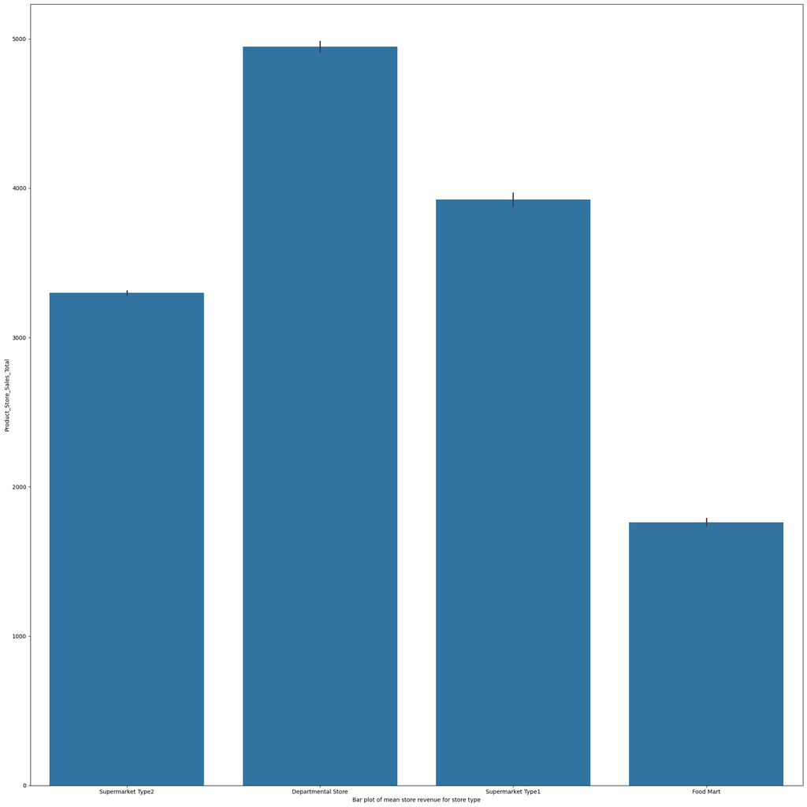

```python
plt.figure(figsize=(20,20))
sns.barplot(df, x = "Store_Type", y = "Product_Store_Sales_Total")
plt.xlabel("Bar plot of mean store revenue for store type")
plt.tight_layout()
plt.show()
```

This barplot shows the average revenue brought in on a particular sale for a product for each store type. The type of store with the highest average revenue is the department store type.

```python
rev_fraction = []
for i in df["Store_Location_City_Type"].unique():
  dummy_df = df.loc[df["Store_Location_City_Type"] == i]
  store_type_rev = dummy_df["Product_Store_Sales_Total"].sum()
  rev_fraction.append(store_type_rev)
  print(store_type_rev, i)
#df2.head()
```

```
21650696.61 Tier 2
6673457.57 Tier 1
2030909.72 Tier 3
```

```python
store_location_type_rev_data = {"Store_Location_City_Type" : df["Store_Location_City_Type"].unique(),
                         "Revenue_For_Type": rev_fraction}

store_location_type_rev_df = pd.DataFrame(store_location_type_rev_data)

store_location_type_rev_df.head()
```

|  | Store_Location_City_Type | Revenue_For_Type |
| --- | --- | --- |
| 0 | Tier 2 | 21650696.61 |
| 1 | Tier 1 | 6673457.57 |
| 2 | Tier 3 | 2030909.72 |

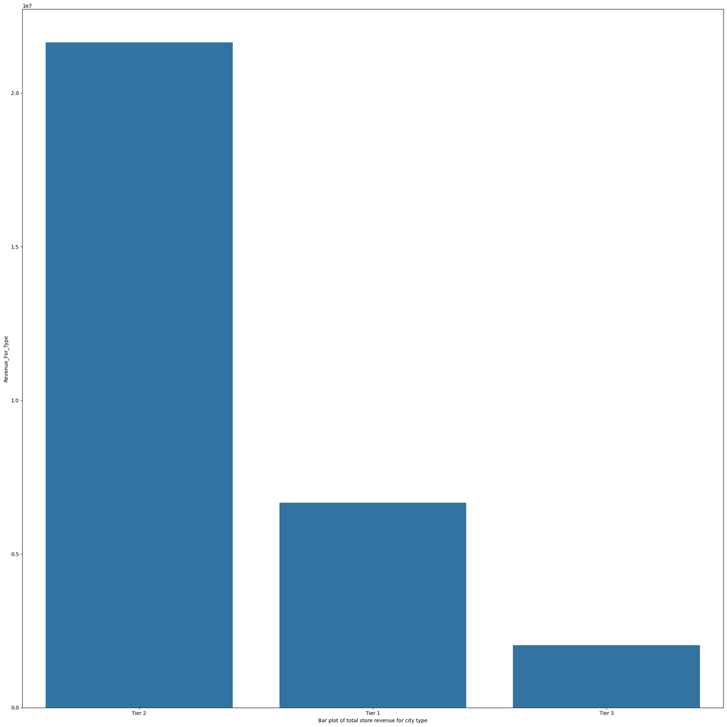

```python
plt.figure(figsize=(20,20))
sns.barplot(store_location_type_rev_df, x = "Store_Location_City_Type", y ="Revenue_For_Type")
plt.xlabel("Bar plot of total store revenue for city type")
plt.tight_layout()
plt.show()
```

This barplot shows the total revenue brought in for each location city type. The type of store that brought in the most total revenue is the tier 2 store location type.

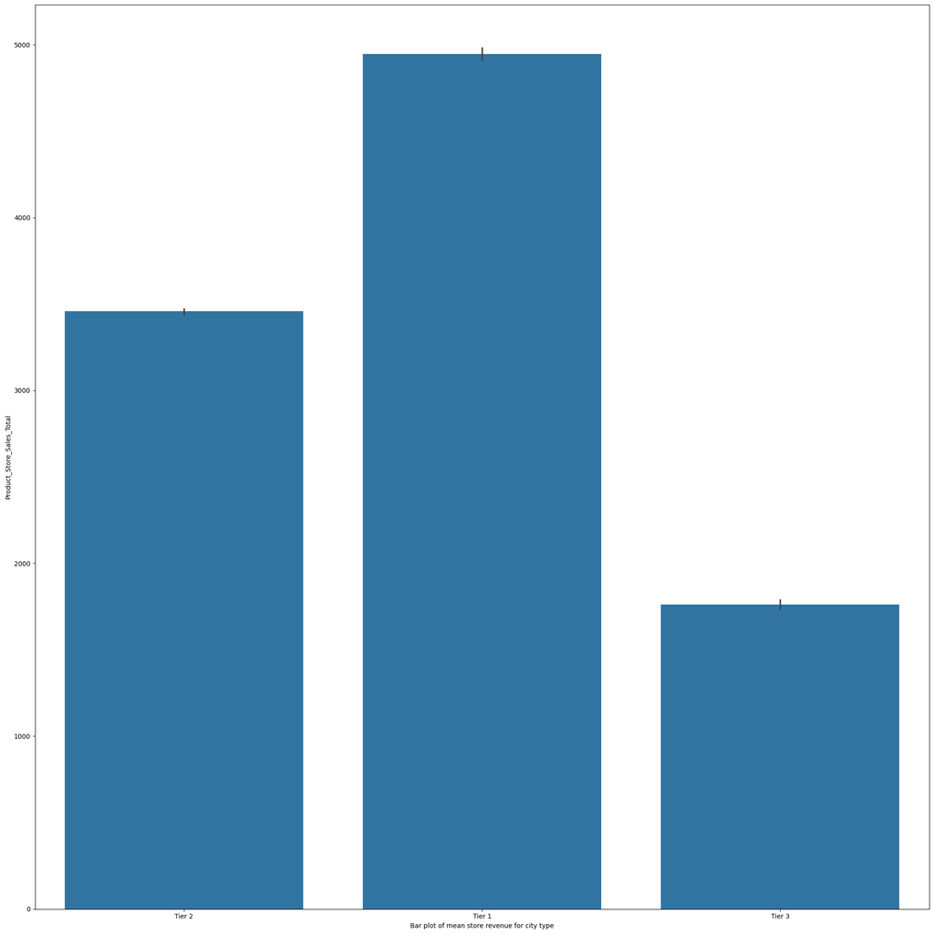

```python
plt.figure(figsize=(20,20))
sns.barplot(df, x = "Store_Location_City_Type", y = "Product_Store_Sales_Total")
plt.xlabel("Bar plot of mean store revenue for city type")
plt.tight_layout()
plt.show()
```

This barplot shows the average revenue brought in from a product at each store location city type. The type of store that brought in the most average revenue is tier 1 type stores

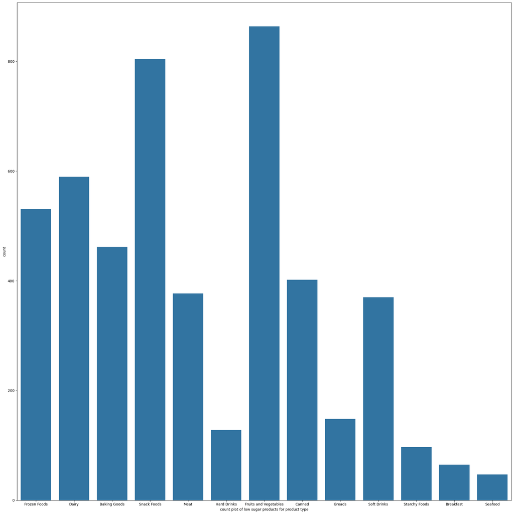

```python
low_sugar_df = df.loc[df["Product_Sugar_Content"] == "Low Sugar"]
plt.figure(figsize=(20,20))
sns.countplot(low_sugar_df, x = "Product_Type")
plt.xlabel("count plot of low sugar products for product type")
plt.tight_layout()
plt.show()
```

This is the number of low sugar products sold for each product type

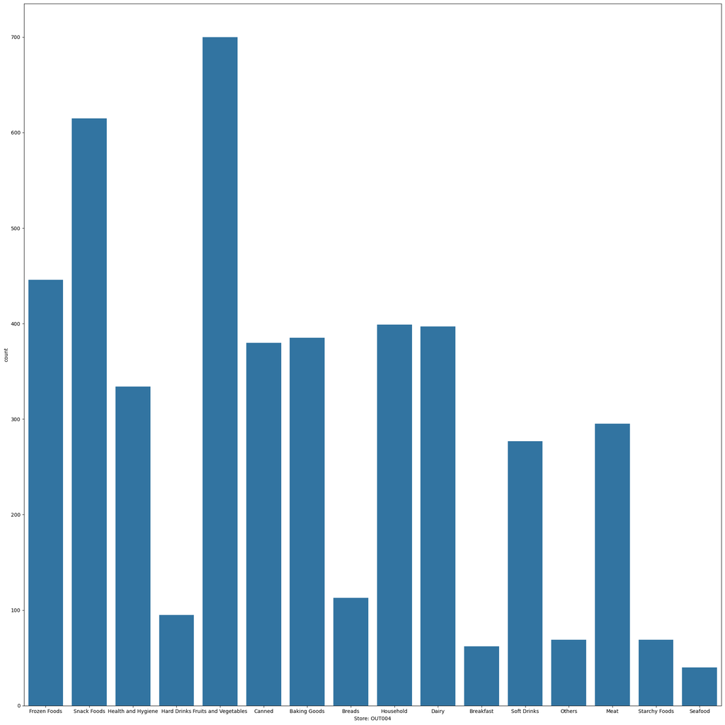

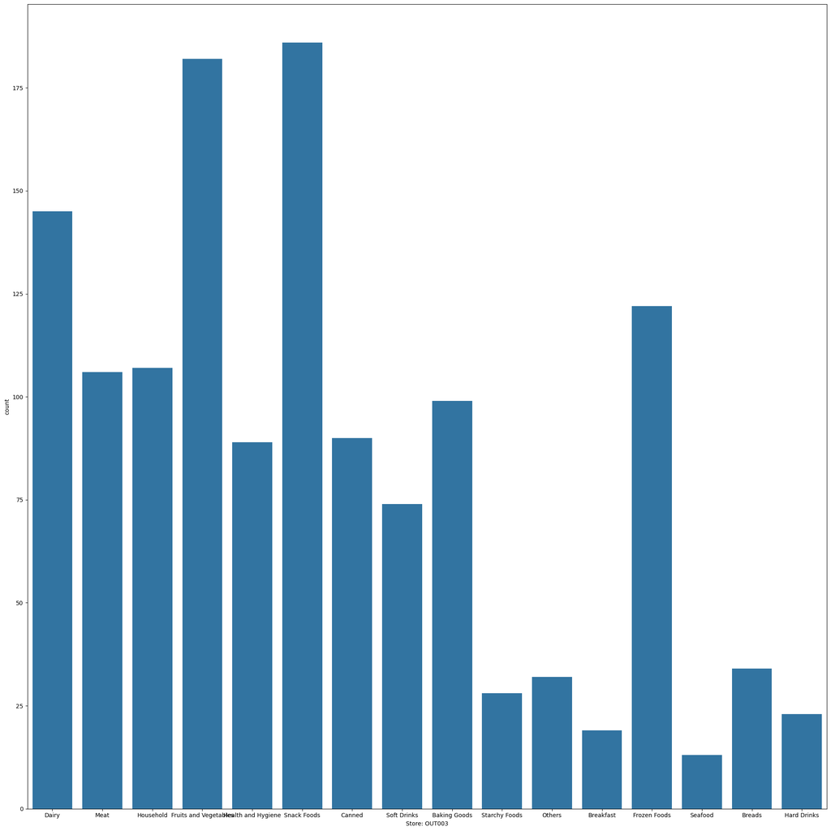

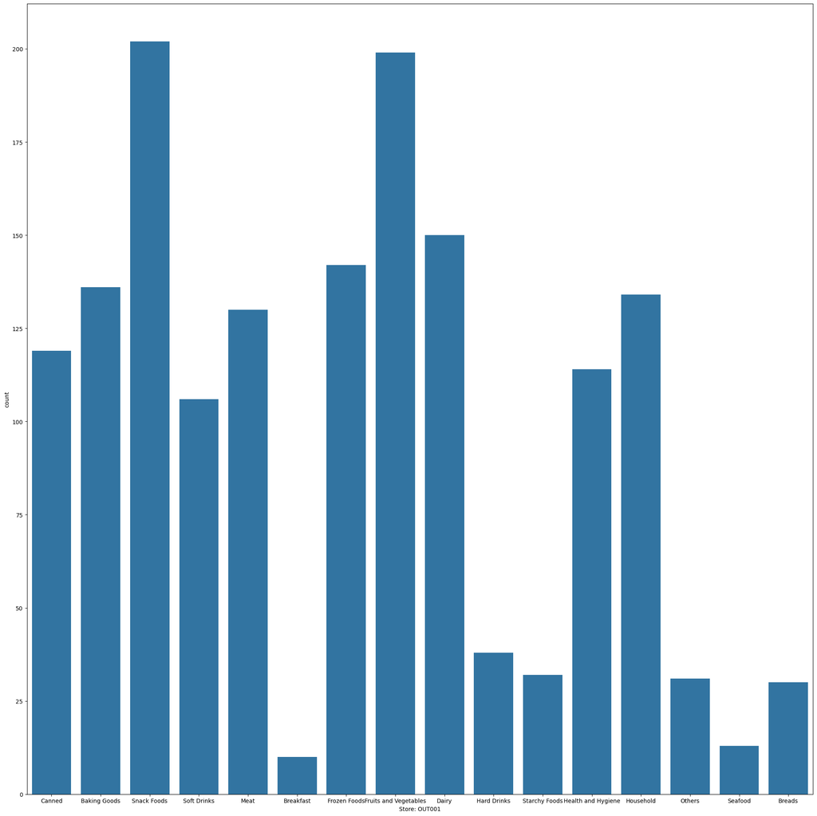

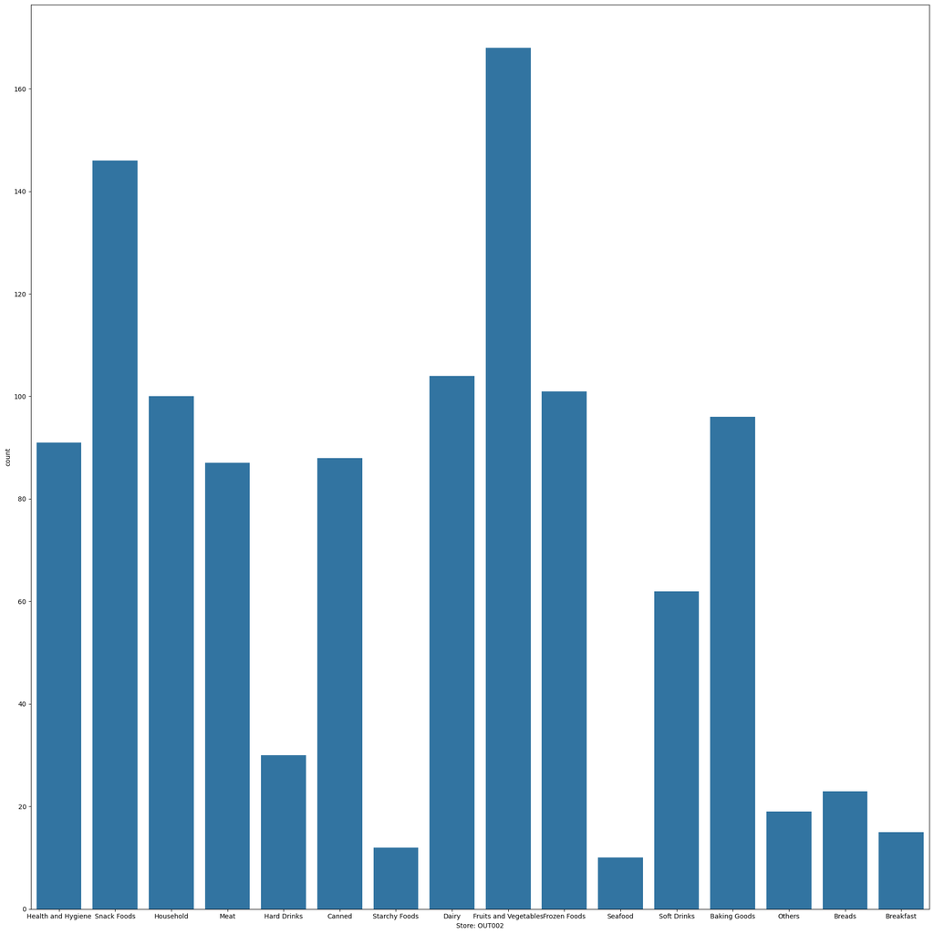

```python
for i in df["Store_Id"].unique():
  dummy_df = df.loc[df["Store_Id"] == i]
  plt.figure(figsize=(20,20))
  sns.countplot(dummy_df, x = "Product_Type")

  plt.xlabel("Store: " + i)
  plt.tight_layout()
  plt.show()
```

This is the countplot for each individual store. Shown is the number of product sales for each product type.

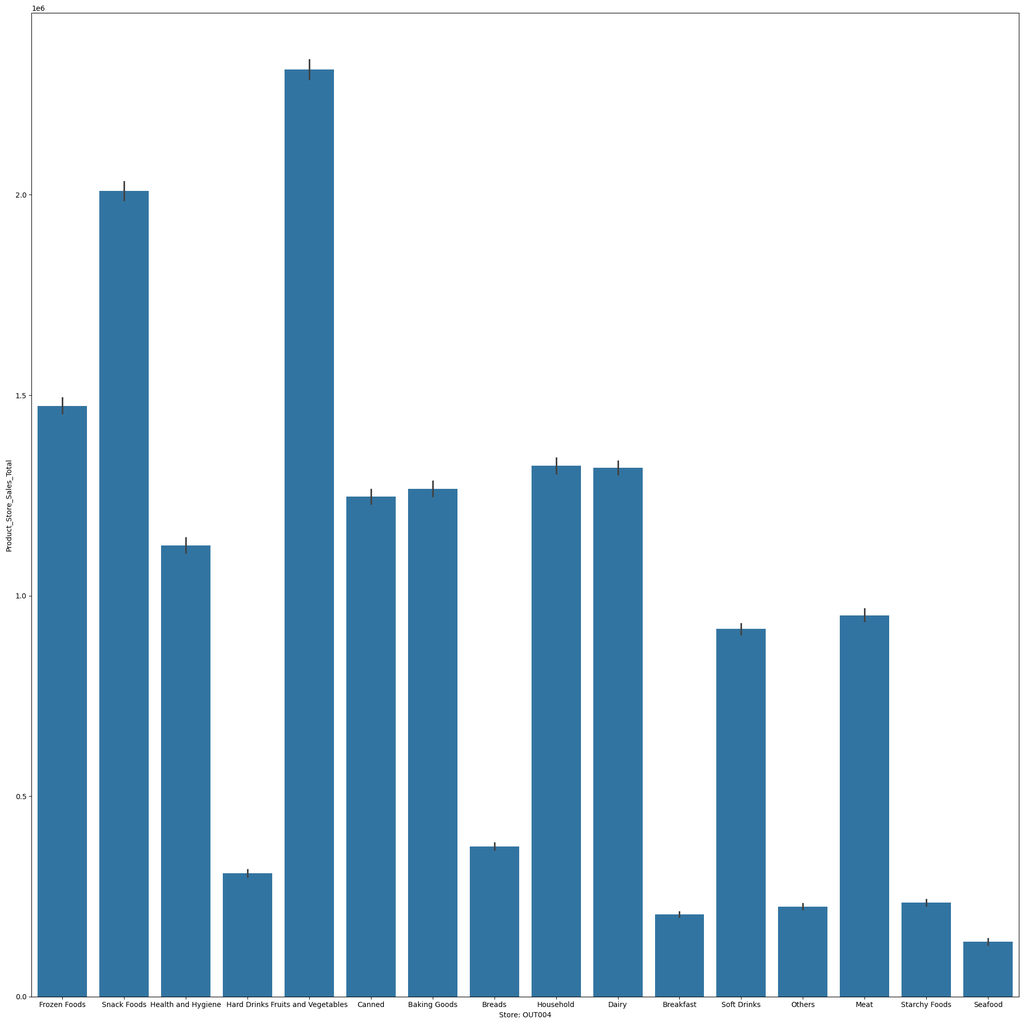

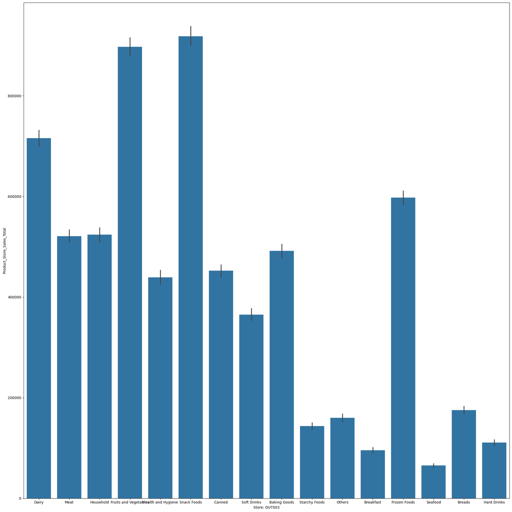

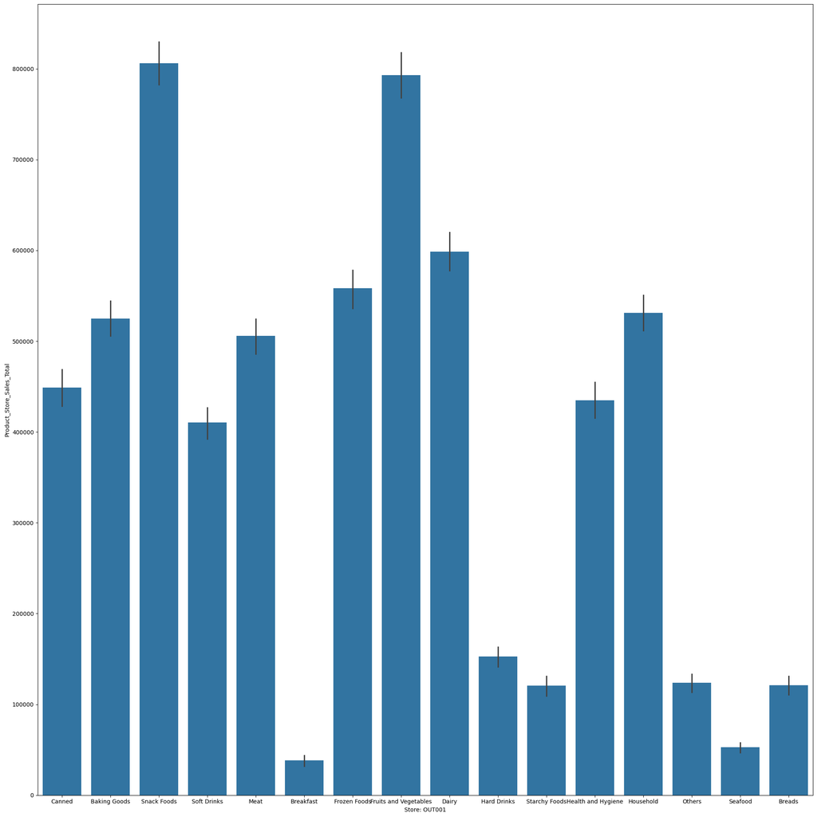

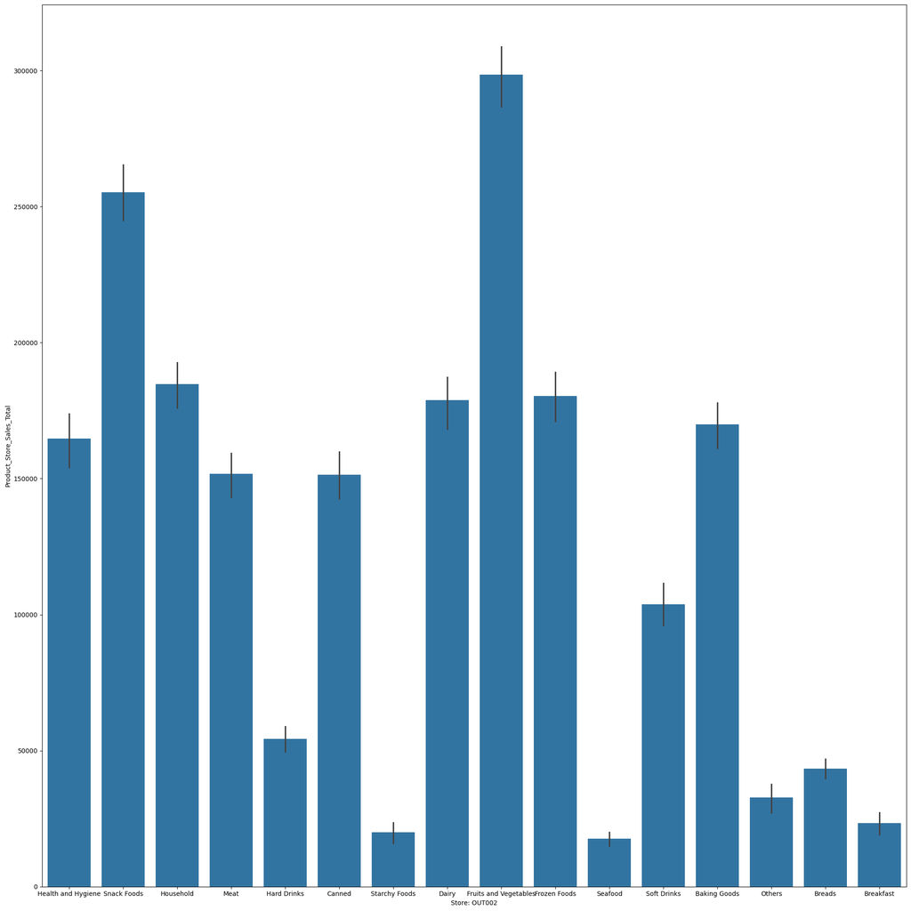

```python
for i in df["Store_Id"].unique():
  dummy_df = df.loc[df["Store_Id"] == i]
  plt.figure(figsize=(20,20))
  sns.barplot(dummy_df, x = "Product_Type", y = "Product_Store_Sales_Total", estimator = "sum")
  plt.xlabel("Store: " + i)
  plt.tight_layout()
  plt.show()
```

This bar plot shows the total revenue generated for each store when categorized by product type.

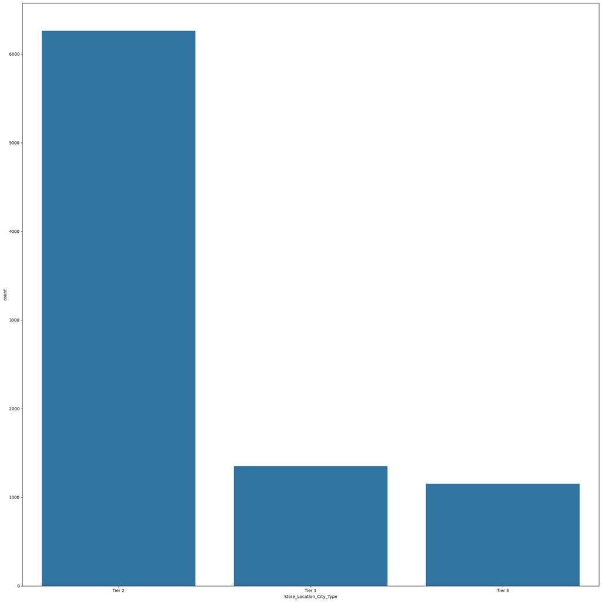

```python
plt.figure(figsize=(20,20))
sns.countplot(df, x = "Store_Location_City_Type")

plt.tight_layout()
plt.show()
```

This is the countplot for each location tier

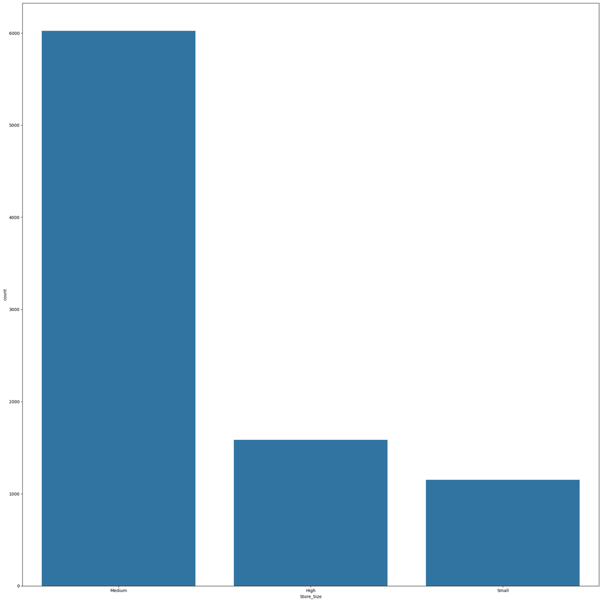

```python
plt.figure(figsize=(20,20))
sns.countplot(df, x = "Store_Size")

plt.tight_layout()
plt.show()
```

This is the countplot for each type of store size

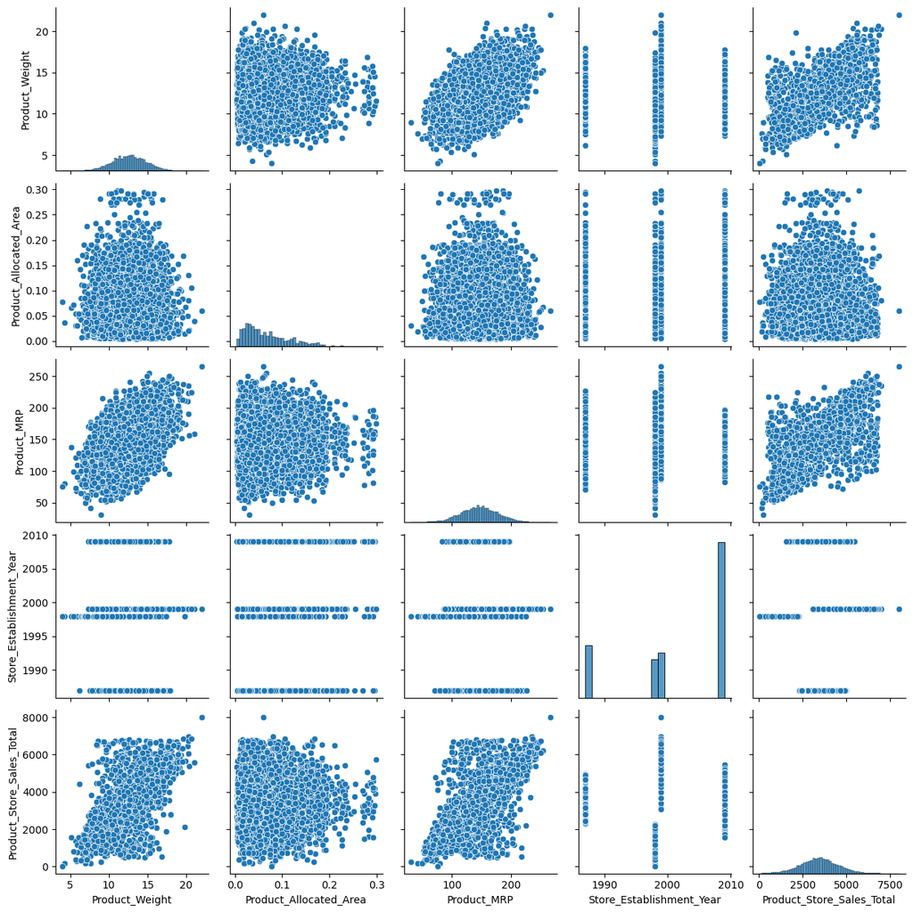

```python
sns.pairplot(df)
```

This is a grid of scatterplots that shows correlation between each of the numeric variables in the dataset. There are only 3 combinations of variables that each show a slight positive correlation. These combinations are Product MRP and Product Weight, Product Weight and Product Store Sales Total, and Product MRP and Product Store Sales Total. The other combinations of variables do not seem to have any type of linear correlation.

## Data Preprocessing

- Missing value treatment (if needed)
- Outlier detection and treatment (if needed)
- Preparing data for modeling
- Any other preprocessing steps (if needed)

We are deciding to keep outliers because they are valid data.

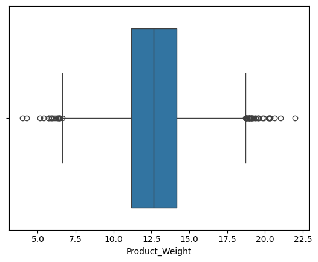

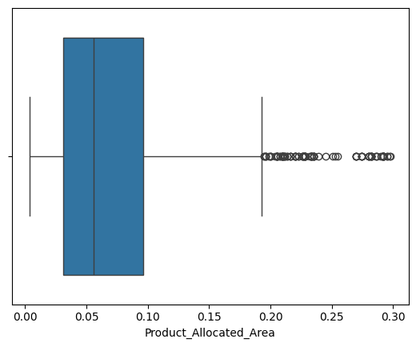

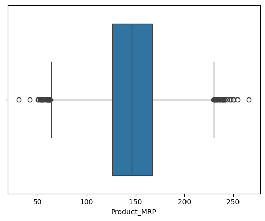

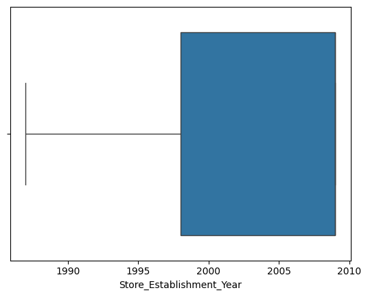

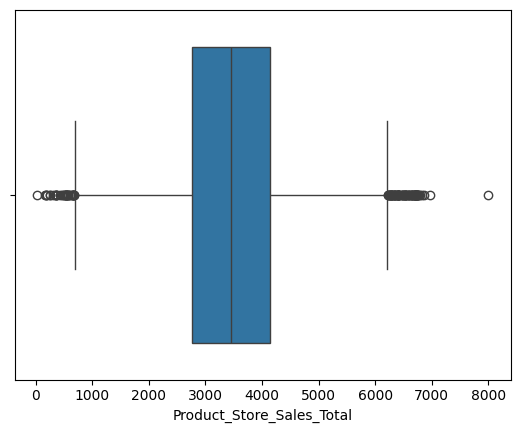

```python
df_numeric_cols = df.select_dtypes(include = np.number)
for i in df_numeric_cols:
  sns.boxplot(data = df_numeric_cols, x = i)
  plt.show()
```

## Feature Engineering

**A store which has been in the business for a long duration is more trustworthy than the newly established ones. On the other hand, older stores may sometimes lack infrastructure if proper attention is not given. So let us calculate the current age of the store and incorporate that in our model.**

```python
df["years running"] = 2024 - df["Store_Establishment_Year"]
```

Dropping certain columns that do not provide insight for our models

```python
df.drop(["Store_Establishment_Year"], axis=1, inplace=True)
```

```python
df.drop(["Product_Id"], axis=1, inplace=True)
```

**We have 16 different product types in our dataset. So let us make two broad categories, perishables and non perishables, in order to reduce the number of product types.**

```python
perishables = [
    "Dairy",
    "Meat",
    "Fruits and Vegetables",
    "Breakfast",
    "Breads",
    "Seafood",
]
```

```python
def change(x):
    if x in perishables:
        return "Perishables"
    else:
        return "Non Perishables"


df["Product_Type"] = df.Product_Type.apply(change)
```

```python
df["Product_Type"].unique()
```

```
array(['Non Perishables', 'Perishables'], dtype=object)
```

```python
change1 = []
for i in range(0, len(df)):
    if df.Product_Type[i] in perishables:
        change1.append("Perishables")
    else:
        change1.append("Non Perishables")
```

```python
# defining X and y variables
X = df.drop(["Product_Store_Sales_Total"], axis=1)
y = df["Product_Store_Sales_Total"]

print(X.head())
print(y.head())
```

```
   Product_Weight Product_Sugar_Content  Product_Allocated_Area  \
0           12.66             Low Sugar                   0.027
1           16.54             Low Sugar                   0.144
2           14.28               Regular                   0.031
3           12.10             Low Sugar                   0.112
4            9.57              No Sugar                   0.010

      Product_Type  Product_MRP Store_Id Store_Size Store_Location_City_Type  \
0  Non Perishables       117.08   OUT004     Medium                   Tier 2
1      Perishables       171.43   OUT003     Medium                   Tier 1
2  Non Perishables       162.08   OUT001       High                   Tier 2
3  Non Perishables       186.31   OUT001       High                   Tier 2
4  Non Perishables       123.67   OUT002      Small                   Tier 3

           Store_Type  years running
0   Supermarket Type2             15
1  Departmental Store             25
2   Supermarket Type1             37
3   Supermarket Type1             37
4           Food Mart             26
0    2842.40
1    4830.02
2    4130.16
3    4132.18
4    2279.36
Name: Product_Store_Sales_Total, dtype: float64
```

```python
X = pd.get_dummies(X,drop_first=True)
```

```python
X_train, X_test, Y_train, Y_test = train_test_split(X, y, train_size = 0.10, random_state = 1)
```

```python
def performance_measures(model, x, y):
  predictions = model.predict(x)
  r2 = r2_score(y, predictions)
  n = x.shape[0]
  k = x.shape[1]
  adjusted_r2 = 1 - ((1 - r2) * (n - 1) / (n - k - 1))
  rmse = np.sqrt(mean_squared_error(y, predictions))
  mae = mean_absolute_error(y, predictions)
  mape = np.mean(np.abs(y - predictions) / y) * 100
  performance = {"R Squared": [r2], "Adjusted R Squared": [adjusted_r2], "RMSE": [rmse], "Mean Absolute Error": [mae], "MAPE": [mape]}
  performance = pd.DataFrame(performance)
  performance.index = ["Performance Measures"]
  return performance
```

## Building bagging and boosting models

Below are all the different bagging and boosting models built around regression because the target variable is a continuous numeric variable. The steps for building the models are:

- Build and fit on the training data
- Quantify performance with R-squared, Adjusted R-squared, RMSE, MAE and MAPE scores
- Tune the models with regards to a higher R squared
- Determine which model is the best based on performance on both the training and test data.

```python
dtree = DecisionTreeRegressor(random_state = 1)
dtree.fit(X_train, Y_train)
```

```
DecisionTreeRegressor(random_state=1)
```

```python
dtree_train_performance = performance_measures(dtree, X_train, Y_train)
dtree_train_performance
```

|  | R Squared | Adjusted R Squared | RMSE | Mean Absolute Error | MAPE |
| --- | --- | --- | --- | --- | --- |
| Performance Measures | 1.0 | 1.0 | 0.0 | 0.0 | 0.0 |

```python
dtree_test_performance = performance_measures(dtree, X_test, Y_test)
dtree_test_performance
```

|  | R Squared | Adjusted R Squared | RMSE | Mean Absolute Error | MAPE |
| --- | --- | --- | --- | --- | --- |
| Performance Measures | 0.822669 | 0.822264 | 448.285445 | 191.815385 | 7.685688 |

```python
rfregressor = RandomForestRegressor(random_state = 1)
rfregressor.fit(X_train, Y_train)
```

```
RandomForestRegressor(random_state=1)
```

```python
rf_train_performance = performance_measures(rfregressor, X_train, Y_train)
rf_train_performance
```

|  | R Squared | Adjusted R Squared | RMSE | Mean Absolute Error | MAPE |
| --- | --- | --- | --- | --- | --- |
| Performance Measures | 0.984834 | 0.984516 | 132.194939 | 57.864695 | 2.113324 |

```python
rf_test_performance = performance_measures(rfregressor, X_test, Y_test)
rf_test_performance
```

|  | R Squared | Adjusted R Squared | RMSE | Mean Absolute Error | MAPE |
| --- | --- | --- | --- | --- | --- |
| Performance Measures | 0.898506 | 0.898274 | 339.142411 | 149.941182 | 6.285156 |

```python
aboostregressor = AdaBoostRegressor(random_state = 1)
aboostregressor.fit(X_train, Y_train)
```

```
AdaBoostRegressor(random_state=1)
```

```python
ab_train_performance = performance_measures(aboostregressor, X_train, Y_train)
ab_train_performance
```

|  | R Squared | Adjusted R Squared | RMSE | Mean Absolute Error | MAPE |
| --- | --- | --- | --- | --- | --- |
| Performance Measures | 0.795565 | 0.791271 | 485.357423 | 387.805134 | 13.053246 |

```python
ab_test_performance = performance_measures(aboostregressor, X_test, Y_test)
ab_test_performance
```

|  | R Squared | Adjusted R Squared | RMSE | Mean Absolute Error | MAPE |
| --- | --- | --- | --- | --- | --- |
| Performance Measures | 0.776539 | 0.776028 | 503.225915 | 401.725916 | 14.490773 |

```python
gboostregressor = GradientBoostingRegressor(random_state = 1)
gboostregressor.fit(X_train, Y_train)
```

```
GradientBoostingRegressor(random_state=1)
```

```python
gb_train_performance = performance_measures(gboostregressor, X_train, Y_train)
gb_train_performance
```

|  | R Squared | Adjusted R Squared | RMSE | Mean Absolute Error | MAPE |
| --- | --- | --- | --- | --- | --- |
| Performance Measures | 0.941441 | 0.940211 | 259.764524 | 136.07701 | 4.345844 |

```python
gb_test_performance = performance_measures(gboostregressor, X_test, Y_test)
gb_test_performance
```

|  | R Squared | Adjusted R Squared | RMSE | Mean Absolute Error | MAPE |
| --- | --- | --- | --- | --- | --- |
| Performance Measures | 0.886061 | 0.8858 | 359.334318 | 190.071548 | 7.260617 |

As we can see from the performance measures, there are large gaps between the R-squared for the training dataset and the R-squared for the test dataset. This indicates overfitting on the training dataset, which works well, but only for the training dataset. We want to see if we can achieve a smaller gap between the two by tuning the models using a hyperparameter grid and using grid search cross validation method

## Will tuning the hyperparameters improve the model performance?

```python
dtree_for_tuning = DecisionTreeRegressor(random_state = 1)

parameters_grid = {'max_depth': np.arange(2,25),
              'min_samples_leaf': [1, 3, 5, 7, 10],
              'max_leaf_nodes': [1, 5, 10, 15],
              'min_impurity_decrease': [0.1, 0.01, 0.5, 0.0]}

scorer = metrics.make_scorer(metrics.r2_score)

grid = GridSearchCV(dtree_for_tuning, parameters_grid, scoring = scorer, cv = 5)
grid = grid.fit(X_train, Y_train)

tuned_dtree = grid.best_estimator_

tuned_dtree.fit(X_train, Y_train)
```

```
DecisionTreeRegressor(max_depth=6, max_leaf_nodes=15, min_impurity_decrease=0.1,
                      min_samples_leaf=3, random_state=1)
```

```python
rf_for_tuning = RandomForestRegressor(random_state = 1)

parameters_grid = {'max_depth':[4, 6, 8, 10],
                'max_features': ['sqrt','log2'],
                'n_estimators': [80, 90, 100]}

scorer = metrics.make_scorer(metrics.r2_score)

grid = GridSearchCV(rf_for_tuning, parameters_grid, scoring = scorer, cv = 5)
grid = grid.fit(X_train, Y_train)

tuned_rf = grid.best_estimator_

tuned_rf.fit(X_train, Y_train)
```

```
RandomForestRegressor(max_depth=10, max_features='sqrt', random_state=1)
```

```python
ab_for_tuning = AdaBoostRegressor(random_state = 1)

parameters_grid = {'n_estimators': np.arange(10,100,10),
              'learning_rate': [1, 0.1, 0.5, 0.01]}

scorer = metrics.make_scorer(metrics.r2_score)

grid = GridSearchCV(ab_for_tuning, parameters_grid, scoring = scorer, cv = 5)
grid = grid.fit(X_train, Y_train)

tuned_ab = grid.best_estimator_

tuned_ab.fit(X_train, Y_train)
```

```
AdaBoostRegressor(learning_rate=0.01, n_estimators=80, random_state=1)
```

```python
gb_for_tuning = GradientBoostingRegressor(random_state = 1)

parameters_grid = {'n_estimators': [100, 150],
              'subsample':[0.5, 0.7],
              'max_features':[0.5, 0.7],
              'max_depth':[3,5,7]}

scorer = metrics.make_scorer(metrics.r2_score)

grid = GridSearchCV(gb_for_tuning, parameters_grid, scoring = scorer, cv = 5)
grid = grid.fit(X_train, Y_train)

tuned_gb = grid.best_estimator_

tuned_gb.fit(X_train, Y_train)
```

```
GradientBoostingRegressor(max_depth=7, max_features=0.7, random_state=1,
                          subsample=0.7)
```

## Model Performance Comparison and Conclusions

```python
tuned_dtree_train_performance = performance_measures(tuned_dtree, X_train, Y_train)
tuned_dtree_train_performance
```

|  | R Squared | Adjusted R Squared | RMSE | Mean Absolute Error | MAPE |
| --- | --- | --- | --- | --- | --- |
| Performance Measures | 0.877102 | 0.874521 | 376.318574 | 250.486109 | 8.57902 |

```python
tuned_dtree_test_performance = performance_measures(tuned_dtree, X_test, Y_test)
tuned_dtree_test_performance
```

|  | R Squared | Adjusted R Squared | RMSE | Mean Absolute Error | MAPE |
| --- | --- | --- | --- | --- | --- |
| Performance Measures | 0.834021 | 0.833641 | 433.699879 | 283.514497 | 11.007229 |

```python
print(pd.DataFrame(tuned_dtree.feature_importances_, columns = ["Imp"], index = X_train.columns).sort_values(by = 'Imp', ascending = False))
```

```
                                      Imp
Product_MRP                      0.487792
Store_Location_City_Type_Tier 3  0.236826
years running                    0.144615
Store_Id_OUT003                  0.081995
Product_Weight                   0.048773
Product_Sugar_Content_Regular    0.000000
Product_Sugar_Content_reg        0.000000
Product_Type_Perishables         0.000000
Store_Id_OUT002                  0.000000
Product_Allocated_Area           0.000000
Store_Id_OUT004                  0.000000
Store_Size_Medium                0.000000
Store_Size_Small                 0.000000
Store_Location_City_Type_Tier 2  0.000000
Product_Sugar_Content_No Sugar   0.000000
Store_Type_Food Mart             0.000000
Store_Type_Supermarket Type1     0.000000
Store_Type_Supermarket Type2     0.000000
```

```python
tuned_rf_train_performance = performance_measures(tuned_rf, X_train, Y_train)
tuned_rf_train_performance
```

|  | R Squared | Adjusted R Squared | RMSE | Mean Absolute Error | MAPE |
| --- | --- | --- | --- | --- | --- |
| Performance Measures | 0.965685 | 0.964965 | 198.848775 | 124.006787 | 4.216141 |

```python
tuned_rf_test_performance = performance_measures(tuned_rf, X_test, Y_test)
tuned_rf_test_performance
```

|  | R Squared | Adjusted R Squared | RMSE | Mean Absolute Error | MAPE |
| --- | --- | --- | --- | --- | --- |
| Performance Measures | 0.886769 | 0.88651 | 358.215498 | 219.396454 | 8.705941 |

```python
tuned_ab_train_performance = performance_measures(tuned_ab, X_train, Y_train)
tuned_ab_train_performance
```

|  | R Squared | Adjusted R Squared | RMSE | Mean Absolute Error | MAPE |
| --- | --- | --- | --- | --- | --- |
| Performance Measures | 0.833492 | 0.829995 | 438.027263 | 322.302607 | 10.564609 |

```python
tuned_ab_test_performance = performance_measures(tuned_ab, X_test, Y_test)
tuned_ab_test_performance
```

|  | R Squared | Adjusted R Squared | RMSE | Mean Absolute Error | MAPE |
| --- | --- | --- | --- | --- | --- |
| Performance Measures | 0.82604 | 0.825642 | 444.004471 | 324.185533 | 12.26159 |

```python
tuned_gb_train_performance = performance_measures(tuned_gb, X_train, Y_train)
tuned_gb_train_performance
```

|  | R Squared | Adjusted R Squared | RMSE | Mean Absolute Error | MAPE |
| --- | --- | --- | --- | --- | --- |
| Performance Measures | 0.998732 | 0.998705 | 38.227521 | 26.157749 | 0.82454 |

```python
tuned_gb_test_performance = performance_measures(tuned_gb, X_test, Y_test)
tuned_gb_test_performance
```

|  | R Squared | Adjusted R Squared | RMSE | Mean Absolute Error | MAPE |
| --- | --- | --- | --- | --- | --- |
| Performance Measures | 0.893475 | 0.893231 | 347.44689 | 170.686558 | 6.831201 |

```python
estimators=[('Decision Tree', tuned_dtree),('Random Forest', tuned_rf),
           ('Gradient Boosting', tuned_gb)]
final_estimator=XGBRegressor(random_state=1)
```

Finally, we are going to build a stacking regressor which takes predictions from the three best models (the tuned versions of the decision tree, random forest, and gradient boost) and feeds them into the meta regressor (an XGBoost model) for a final result.

```python
stacking_estimator=StackingRegressor(estimators=estimators, final_estimator=final_estimator,cv=5)
stacking_estimator.fit(X_train,Y_train)
```

```
StackingRegressor(cv=5,
                  estimators=[('Decision Tree',
                               DecisionTreeRegressor(max_depth=6,
                                                     max_leaf_nodes=15,
                                                     min_impurity_decrease=0.1,
                                                     min_samples_leaf=3,
                                                     random_state=1)),
                              ('Random Forest',
                               RandomForestRegressor(max_depth=10,
                                                     max_features='sqrt',
                                                     random_state=1)),
                              ('Gradient Boosting',
                               GradientBoostingRegressor(max_depth=7,
                                                         max_features=0.7,
                                                         random_state=1,
                                                         subsamp...
                                               feature_types=None, gamma=None,
                                               grow_policy=None,
                                               importance_type=None,
                                               interaction_constraints=None,
                                               learning_rate=None, max_bin=None,
                                               max_cat_threshold=None,
                                               max_cat_to_onehot=None,
                                               max_delta_step=None,
                                               max_depth=None, max_leaves=None,
                                               min_child_weight=None,
                                               missing=nan,
                                               monotone_constraints=None,
                                               multi_strategy=None,
                                               n_estimators=None, n_jobs=None,
                                               num_parallel_tree=None,
                                               random_state=1, ...))
```

```python
stacking_performance = performance_measures(stacking_estimator, X_train, Y_train)
stacking_performance
```

|  | R Squared | Adjusted R Squared | RMSE | Mean Absolute Error | MAPE |
| --- | --- | --- | --- | --- | --- |
| Performance Measures | 0.932724 | 0.931311 | 278.428429 | 153.021131 | 5.09091 |

```python
stacking_performance = performance_measures(stacking_estimator, X_test, Y_test)
stacking_performance
```

|  | R Squared | Adjusted R Squared | RMSE | Mean Absolute Error | MAPE |
| --- | --- | --- | --- | --- | --- |
| Performance Measures | 0.825931 | 0.825532 | 444.143965 | 247.234599 | 9.010744 |

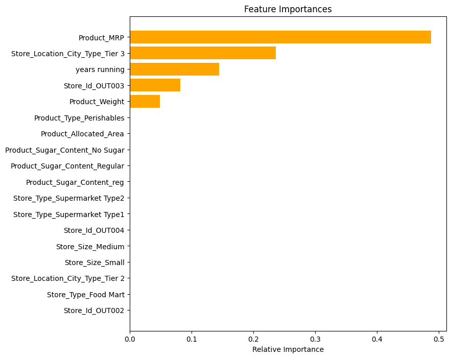

```python
feature_names = list(X_train.columns)
importances = tuned_dtree.feature_importances_
indices = np.argsort(importances)

plt.figure(figsize=(8, 8))
plt.title("Feature Importances")
plt.barh(range(len(indices)), importances[indices], color="orange", align="center")
plt.yticks(range(len(indices)), [feature_names[i] for i in indices])
plt.xlabel("Relative Importance")
plt.show()
```

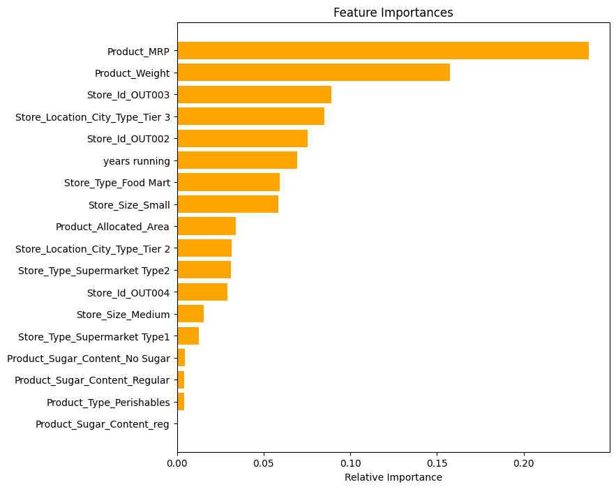

```python
feature_names = list(X_train.columns)
importances = tuned_rf.feature_importances_
indices = np.argsort(importances)

plt.figure(figsize=(8, 8))
plt.title("Feature Importances")
plt.barh(range(len(indices)), importances[indices], color="orange", align="center")
plt.yticks(range(len(indices)), [feature_names[i] for i in indices])
plt.xlabel("Relative Importance")
plt.show()
```

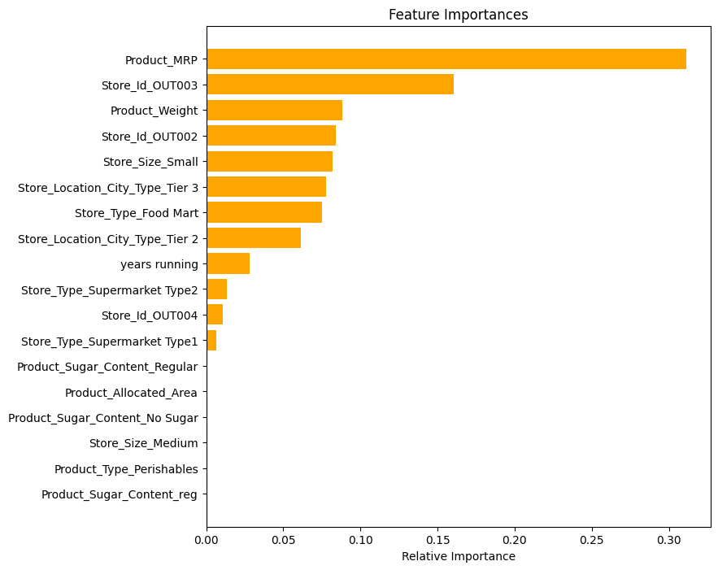

```python
feature_names = list(X_train.columns)
importances = tuned_ab.feature_importances_
indices = np.argsort(importances)

plt.figure(figsize=(8, 8))
plt.title("Feature Importances")
plt.barh(range(len(indices)), importances[indices], color="orange", align="center")
plt.yticks(range(len(indices)), [feature_names[i] for i in indices])
plt.xlabel("Relative Importance")
plt.show()
```

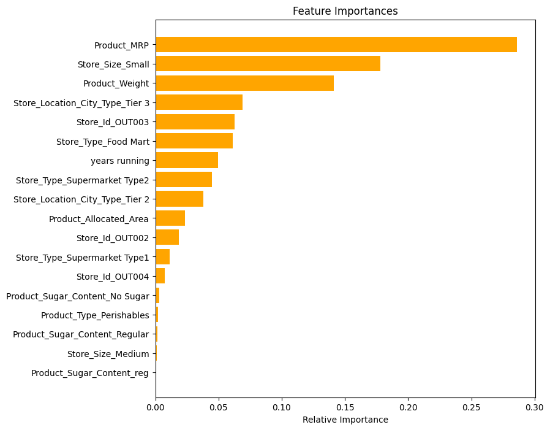

```python
feature_names = list(X_train.columns)
importances = tuned_gb.feature_importances_
indices = np.argsort(importances)

plt.figure(figsize=(8, 8))
plt.title("Feature Importances")
plt.barh(range(len(indices)), importances[indices], color="orange", align="center")
plt.yticks(range(len(indices)), [feature_names[i] for i in indices])
plt.xlabel("Relative Importance")
plt.show()
```

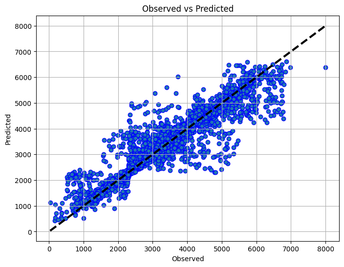

```python
fig, ax = plt.subplots(figsize=(8, 6))
y_pred=tuned_gb.predict(X_test)
ax.scatter(Y_test, y_pred, edgecolors=(0, 0, 1))
ax.plot([Y_test.min(), Y_test.max()], [Y_test.min(), Y_test.max()], 'k--', lw=3)
ax.set_xlabel('Observed')
ax.set_ylabel('Predicted')
ax.set_title("Observed vs Predicted")
plt.grid()
plt.show()
```